- [rcourse](http://nbviewer.ipython.org/github/pdparker/rcourse/tree/master) /
- [Regression in R.ipynb](http://nbviewer.ipython.org/github/pdparker/rcourse/tree/master/Regression%20in%20R.ipynb) /

# How to Run Basis Analysis in R

## Contents:

1. [Running basic regression](http://nbviewer.ipython.org/github/pdparker/rcourse/blob/master/Regression%20in%20R.ipynb#regression)
2. [Comparing models](http://nbviewer.ipython.org/github/pdparker/rcourse/blob/master/Regression%20in%20R.ipynb#compare)
3. [Moderation](http://nbviewer.ipython.org/github/pdparker/rcourse/blob/master/Regression%20in%20R.ipynb#moderation)
4. [Polynomial models](http://nbviewer.ipython.org/github/pdparker/rcourse/blob/master/Regression%20in%20R.ipynb#poly)
5. [Mediation models](http://nbviewer.ipython.org/github/pdparker/rcourse/blob/master/Regression%20in%20R.ipynb#mediation)
6. [Running basic general linear models](http://nbviewer.ipython.org/github/pdparker/rcourse/blob/master/Regression%20in%20R.ipynb#glm)
7. [Proportion odds logistic regression](http://nbviewer.ipython.org/github/pdparker/rcourse/blob/master/Regression%20in%20R.ipynb#polr)
8. [Multilevel models](http://nbviewer.ipython.org/github/pdparker/rcourse/blob/master/Regression%20in%20R.ipynb#multilevel)
9. [General linear multilevel models](http://nbviewer.ipython.org/github/pdparker/rcourse/blob/master/Regression%20in%20R.ipynb#glmer)

## In this session

In this session we will go through:

- Running regressions
- Comparing models
- Running moderation
- Running mediation
- General linear models
- Multilevel models - linear and logitistic

```python
#ignore python vodoo occuring in the cell
%load_ext rmagic
```

```
The rmagic extension is already loaded. To reload it, use:
  %reload_ext rmagic
```

## Ipython notebooks

Please note that today I will be running R from within python not Rstudio. The sole purpose of this is so I can run R code dynamically from within the slides as we go. But also because the output is pretty long so does not fit easily on a powerpoint slide.

So you will see some unusual things -- mainly I will use the print statement ALOT. You won't need to use the print statement. Simple R files containing the code are avaliable in the templates file folder.

Also you will see the symbol '%%R' this is python vodoo to make python run R. So you will not need that either!

## Top Tips for running regression

1. Almost ALL model functions will have the following structure $response \sim predictor + predictor$
2. Once models are run you can pass them to summary() OR plot() OR residuals() OR coef() OR confint() OR predict() OR lm.beta()
3. Standardized betas come from the lm.beta() function that is in the QuantPsyc package
4. Interactions can be defined in models short hand via $response \sim predictor * predictor$ or long hand $response \sim predictor + predictor + predictor:predictor$
5. You can make ANY transformation you want directly in the model including polynomials, interactions, log transformations, z-scores
6. To compare the fit of nested models use anova()
7. To calculate simple slopes use deltaMethod() in the car package
8. To calculate mediation use the mediation package

top

```python
%%R
#change the working directory
print(getwd())
setwd("/Users/phparker/Dropbox/Rcourse/data/")
print(getwd())
```

```
[1] "/Users/phparker/Dropbox/Rcourse/data"
[1] "/Users/phparker/Dropbox/Rcourse/data"
```

```python
%%R
#read in the data we need
library(foreign)
ach <- read.spss("PISA2003-Achievement.sav", to.data.frame = TRUE, use.value.labels = FALSE)
psych <- read.spss("PISA2003.sav", to.data.frame = TRUE, use.value.labels = FALSE)
pisa <- merge(ach,psych, by = "STIDSTD")
print(names(pisa))
```

```
re-encoding from UTF-8
re-encoding from UTF-8
 [1] "STIDSTD"      "SCHOOLID.x"   "PV1MATH"      "PV2MATH"      "PV3MATH"
 [6] "PV4MATH"      "PV5MATH"      "PV1READ"      "PV2READ"      "PV3READ"
[11] "PV4READ"      "PV5READ"      "PV1SCIE"      "PV2SCIE"      "PV3SCIE"
[16] "PV4SCIE"      "PV5SCIE"      "PV1PROB"      "PV2PROB"      "PV3PROB"
[21] "PV4PROB"      "PV5PROB"      "W_FSTUWT.x"   "SCHOOLID.y"   "yearInSchool"
[26] "gender"       "BSMJ"         "HISEI"        "MSECATEG"     "FSECATEG"
[31] "HSECATEG"     "SSECATEG"     "HISCED"       "PARED"        "IMMIG"
[36] "LANGN"        "SISCED"       "MMINS"        "TMINS"        "PCMATH"
[41] "RMHMWK"       "COMPHOME"     "CULTPOSS"     "HEDRES"       "HOMEPOS"
[46] "ATSCHL"       "STUREL"       "BELONG"       "INTMAT"       "INSTMOT"
[51] "MATHEFF"      "ANXMAT"       "SCMAT"        "CSTRAT"       "ELAB"
[56] "MEMOR"        "COMPLRN"      "COOPLRN"      "TEACHSUP"     "DISCLIM"
[61] "ATTCOMP"      "ESCS"         "W_FSTUWT.y"
```

Regression is run with the command lm. Associated with this is glm for logistic regression, etc. t.test, and aov for anova's.

All this models have a straightforward syntax for building a model:

responseVariable ~ predictor1 + predictor2, data=theDataYouAreUsing, additionalOptions.

Lets start by looking at the effects of different achievement domains on self-concept.

```
Call:
lm(formula = SCMAT ~ PV1MATH + PV1READ + PV1SCIE, data = pisa)

Residuals:
     Min       1Q   Median       3Q      Max
-2.55580 -0.47623  0.01597  0.48038  2.80772

Coefficients:
              Estimate Std. Error t value Pr(>|t|)
(Intercept) -1.6746968  0.1445446 -11.586  < 2e-16 ***
PV1MATH      0.0058793  0.0004866  12.082  < 2e-16 ***
PV1READ     -0.0037377  0.0004834  -7.732 2.28e-14 ***
PV1SCIE      0.0012786  0.0005321   2.403   0.0164 *
---
Signif. codes:  0 ‘***’ 0.001 ‘**’ 0.01 ‘*’ 0.05 ‘.’ 0.1 ‘ ’ 1

Residual standard error: 0.8281 on 1163 degrees of freedom
  (13 observations deleted due to missingness)
Multiple R-squared:  0.2093,	Adjusted R-squared:  0.2072
F-statistic: 102.6 on 3 and 1163 DF,  p-value: < 2.2e-16
```

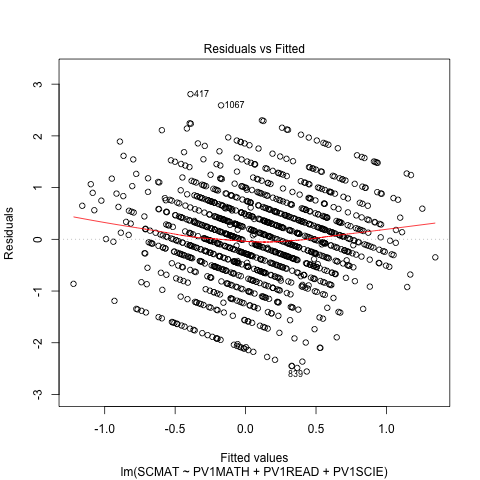

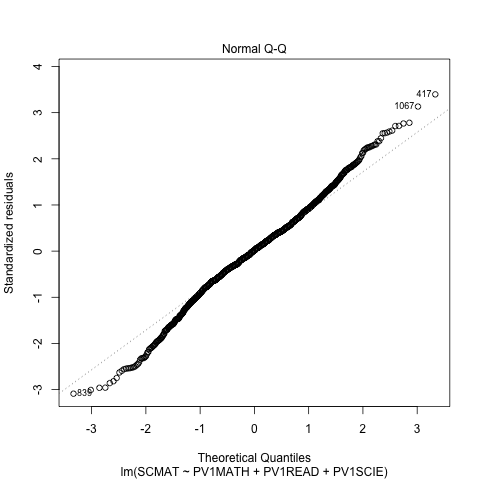

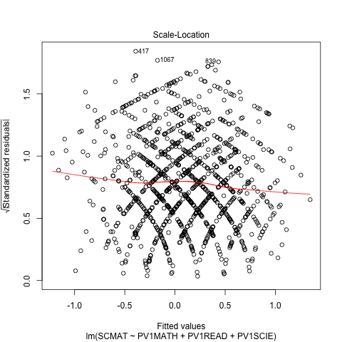

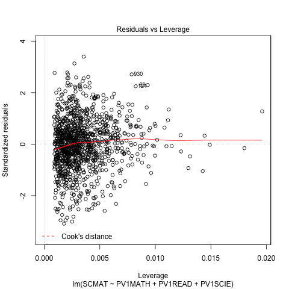

```python
%%R
#Run ther model and save it to an object
model1 <- lm(SCMAT ~ PV1MATH + PV1READ + PV1SCIE, data = pisa)
#Return the output
print(summary(model1))
#Check the assumptions
plot(model1)
```

Notice how small the coefficents are. This is becuase achievement is on a very large scale. So we should fix this somehow. We could:

- Z score the achievement scores
- Devide them by a large number

We also have to choices on how to do this:

- On the fly in the model command
- Change the variables

top

```python
%%R
# Here are our original coefficents
print(coef(model1))
#Z score on the fly
model2 <- lm(SCMAT ~ scale(PV1MATH) + scale(PV1READ) +
             scale(PV1SCIE), data = pisa)
#Return the output
print(coef(model2))

# Change metric on the fly
model3 <- lm(SCMAT ~ I(PV1MATH/100) + I(PV1READ/100) +
             I(PV1SCIE/100), data = pisa)
#Return the output
print(coef(model3))

# we could also get the standardized beta's
library(QuantPsyc)
print(lm.beta(model1))
```

```
 (Intercept)      PV1MATH      PV1READ      PV1SCIE
-1.674696812  0.005879304 -0.003737655  0.001278580
   (Intercept) scale(PV1MATH) scale(PV1READ) scale(PV1SCIE)
    0.09301875     0.55691517    -0.36926255     0.13137109
   (Intercept) I(PV1MATH/100) I(PV1READ/100) I(PV1SCIE/100)
    -1.6746968      0.5879304     -0.3737655      0.1278580
   PV1MATH    PV1READ    PV1SCIE
 0.5926839 -0.3900575  0.1391628
```

Things to try:

1. We will almost certinaly want to just use the z-scored achievement so use the apply command with the scale function to z-score ALL of the achievement scores
2. extract the confidence intervals using the function confint()
3. extract the residuals using residuals(). Plot a histogram. Do we meet the assumptions of regbression here?
4. ADVANCED: using predict() plot the predicted SCMAT scores against the observed. Are there any systematic biases?

## Comparing Models

Next we are going to use anova to compare a model with just SES to one with SES and achievement

top

```python
%%R
# first I am going to z-score all achievement scores
pisa[, grep("^PV[1-5].*", names(pisa))] <- apply(pisa[, grep("^PV[1-5].*", names(pisa))],
                                                    2, scale)
# Run the model with just SES
modelSes <- lm(SCMAT ~ ESCS, data = pisa)
print(summary(modelSes))
# Run the model with SES and achievement
modelSesAch <- lm(SCMAT ~ ESCS + PV1MATH + PV1READ + PV1SCIE, data = pisa)
print(summary(modelSesAch))
# Compare the models
print(anova(modelSes, modelSesAch))
```

```
Call:
lm(formula = SCMAT ~ ESCS, data = pisa)

Residuals:
     Min       1Q   Median       3Q      Max
-2.37471 -0.55207  0.01624  0.61167  2.42930

Coefficients:
            Estimate Std. Error t value Pr(>|t|)
(Intercept)  0.06934    0.02844   2.438 0.014910 *
ESCS         0.11485    0.03190   3.601 0.000331 ***
---
Signif. codes:  0 ‘***’ 0.001 ‘**’ 0.01 ‘*’ 0.05 ‘.’ 0.1 ‘ ’ 1

Residual standard error: 0.9256 on 1151 degrees of freedom
  (27 observations deleted due to missingness)
Multiple R-squared:  0.01114,	Adjusted R-squared:  0.01028
F-statistic: 12.97 on 1 and 1151 DF,  p-value: 0.0003308


Call:
lm(formula = SCMAT ~ ESCS + PV1MATH + PV1READ + PV1SCIE, data = pisa)

Residuals:
     Min       1Q   Median       3Q      Max
-2.56370 -0.48024  0.02245  0.49515  2.86100

Coefficients:
            Estimate Std. Error t value Pr(>|t|)
(Intercept)  0.09647    0.02555   3.776 0.000168 ***
ESCS        -0.02276    0.03117  -0.730 0.465521
PV1MATH      0.56017    0.04680  11.971  < 2e-16 ***
PV1READ     -0.36700    0.04865  -7.543 9.32e-14 ***
PV1SCIE      0.13653    0.05520   2.474 0.013518 *
---
Signif. codes:  0 ‘***’ 0.001 ‘**’ 0.01 ‘*’ 0.05 ‘.’ 0.1 ‘ ’ 1

Residual standard error: 0.8283 on 1148 degrees of freedom
  (27 observations deleted due to missingness)
Multiple R-squared:  0.2101,	Adjusted R-squared:  0.2073
F-statistic: 76.33 on 4 and 1148 DF,  p-value: < 2.2e-16

Analysis of Variance Table

Model 1: SCMAT ~ ESCS
Model 2: SCMAT ~ ESCS + PV1MATH + PV1READ + PV1SCIE
  Res.Df    RSS Df Sum of Sq      F    Pr(>F)
1   1151 986.06
2   1148 787.67  3    198.39 96.383 < 2.2e-16 ***
---
Signif. codes:  0 ‘***’ 0.001 ‘**’ 0.01 ‘*’ 0.05 ‘.’ 0.1 ‘ ’ 1
```

## Moderation

Now we are going to run some moderation models. In this case we will ask:

- Is the effect of math achievement on math self-concept weaker or stronger for boys or girls
- What are the simple slopes for boys and girls

top

```python
%%R
#model without moderation
modelMain <- lm(SCMAT ~ PV1MATH + gender, data = pisa)
print(summary(modelMain))
#Model with interaction
modelInt <- lm(SCMAT ~ PV1MATH*I(gender-1), data = pisa)
print(summary(modelInt))
#Compute simple effect
library(car)
print(deltaMethod(modelInt,g = "ach + int*0",vcov. = vcov(modelInt),parameterNames = c("int", "ach", "gen", "int")))
print(deltaMethod(modelInt,g = "ach + int*1",vcov. = vcov(modelInt),parameterNames = c("int", "ach", "gen", "int")))
```

```
Call:
lm(formula = SCMAT ~ PV1MATH + gender, data = pisa)

Residuals:
     Min       1Q   Median       3Q      Max
-2.63863 -0.49760  0.02384  0.49696  2.74510

Coefficients:
            Estimate Std. Error t value Pr(>|t|)
(Intercept) -0.41801    0.07588  -5.509 4.44e-08 ***
PV1MATH      0.38888    0.02467  15.764  < 2e-16 ***
gender       0.34689    0.04891   7.092 2.29e-12 ***
---
Signif. codes:  0 ‘***’ 0.001 ‘**’ 0.01 ‘*’ 0.05 ‘.’ 0.1 ‘ ’ 1

Residual standard error: 0.833 on 1164 degrees of freedom
  (13 observations deleted due to missingness)
Multiple R-squared:  0.1992,	Adjusted R-squared:  0.1978
F-statistic: 144.8 on 2 and 1164 DF,  p-value: < 2.2e-16


Call:
lm(formula = SCMAT ~ PV1MATH * I(gender - 1), data = pisa)

Residuals:
     Min       1Q   Median       3Q      Max
-2.63996 -0.49670  0.02419  0.49848  2.74820

Coefficients:
                       Estimate Std. Error t value Pr(>|t|)
(Intercept)           -0.071001   0.033528  -2.118   0.0344 *
PV1MATH                0.386738   0.035350  10.940  < 2e-16 ***
I(gender - 1)          0.346835   0.048938   7.087 2.37e-12 ***
PV1MATH:I(gender - 1)  0.004179   0.049376   0.085   0.9326
---
Signif. codes:  0 ‘***’ 0.001 ‘**’ 0.01 ‘*’ 0.05 ‘.’ 0.1 ‘ ’ 1

Residual standard error: 0.8334 on 1163 degrees of freedom
  (13 observations deleted due to missingness)
Multiple R-squared:  0.1992,	Adjusted R-squared:  0.1972
F-statistic: 96.44 on 3 and 1163 DF,  p-value: < 2.2e-16

               Estimate        SE
ach + int * 0 0.3867379 0.0353502
               Estimate         SE
ach + int * 1 0.3909168 0.04808803
```

## Polynomials

Maybe achievement predicts SCMAT differently at either end of the achievement spectrum. So lets try a polynomial model.

*Note*: In the poly function below raw = TRUE gives is equivilent to transforming data by hand. raw = FALSE will give the orthoginal polynomial contrasts

top

```python
%%R
#Second order polynomial
modelQuad <- lm(SCMAT ~ PV1MATH + I(PV1MATH^2) , data = pisa)
print(summary(modelQuad) )
#Third Order polynomial
modelPoly <- lm(SCMAT ~ poly(PV1MATH, degree = 3, raw = TRUE) , data = pisa)
print(summary(modelPoly) )
```

```
Call:
lm(formula = SCMAT ~ PV1MATH + I(PV1MATH^2), data = pisa)

Residuals:
     Min       1Q   Median       3Q      Max
-2.67724 -0.48948  0.03265  0.51528  2.81474

Coefficients:
             Estimate Std. Error t value Pr(>|t|)
(Intercept)  0.009509   0.030813   0.309    0.758
PV1MATH      0.392460   0.025088  15.643  < 2e-16 ***
I(PV1MATH^2) 0.083655   0.018775   4.456 9.17e-06 ***
---
Signif. codes:  0 ‘***’ 0.001 ‘**’ 0.01 ‘*’ 0.05 ‘.’ 0.1 ‘ ’ 1

Residual standard error: 0.8437 on 1164 degrees of freedom
  (13 observations deleted due to missingness)
Multiple R-squared:  0.1786,	Adjusted R-squared:  0.1772
F-statistic: 126.6 on 2 and 1164 DF,  p-value: < 2.2e-16


Call:
lm(formula = SCMAT ~ poly(PV1MATH, degree = 3, raw = TRUE), data = pisa)

Residuals:
     Min       1Q   Median       3Q      Max
-2.67249 -0.48528  0.03329  0.51846  2.80885

Coefficients:
                                       Estimate Std. Error t value Pr(>|t|)
(Intercept)                            0.007566   0.031370   0.241    0.809
poly(PV1MATH, degree = 3, raw = TRUE)1 0.382201   0.039684   9.631  < 2e-16 ***
poly(PV1MATH, degree = 3, raw = TRUE)2 0.086258   0.020337   4.242  2.4e-05 ***
poly(PV1MATH, degree = 3, raw = TRUE)3 0.003834   0.011489   0.334    0.739
---
Signif. codes:  0 ‘***’ 0.001 ‘**’ 0.01 ‘*’ 0.05 ‘.’ 0.1 ‘ ’ 1

Residual standard error: 0.844 on 1163 degrees of freedom
  (13 observations deleted due to missingness)
Multiple R-squared:  0.1787,	Adjusted R-squared:  0.1766
F-statistic: 84.35 on 3 and 1163 DF,  p-value: < 2.2e-16
```

## Mediation

Mediation is used a lot in the sort of research we do. Here we are going to look at a general purpose approach to mediation that will work regardless of whether your models are regression, multilevel, logistic, or polr. To do this we will use the mediation package. The good thing about mediation is that it will produce estimates via boot strapping or simulation those overcoming some complaints about the Barron and Kenny method.

The question we will ask is the degree to which the effect of gender on SCMAT is mediated by achievement.

top

```
Causal Mediation Analysis

Quasi-Bayesian Confidence Intervals

                         Estimate 95% CI Lower 95% CI Upper p-value
ACME (control)            -0.0312      -0.0752       0.0114    0.18
ACME (treated)            -0.0318      -0.0754       0.0115    0.18
ADE (control)              0.3533       0.2627       0.4683    0.00
ADE (treated)              0.3527       0.2602       0.4697    0.00
Total Effect               0.3215       0.2250       0.4318    0.00
Prop. Mediated (control)  -0.0994      -0.2826       0.0347    0.18
Prop. Mediated (treated)  -0.1001      -0.2948       0.0343    0.18
ACME (average)            -0.0315      -0.0753       0.0114    0.18
ADE (average)              0.3530       0.2609       0.4690    0.00
Prop. Mediated (average)  -0.0998      -0.2906       0.0348    0.18

Sample Size Used: 1167


Simulations: 100
```

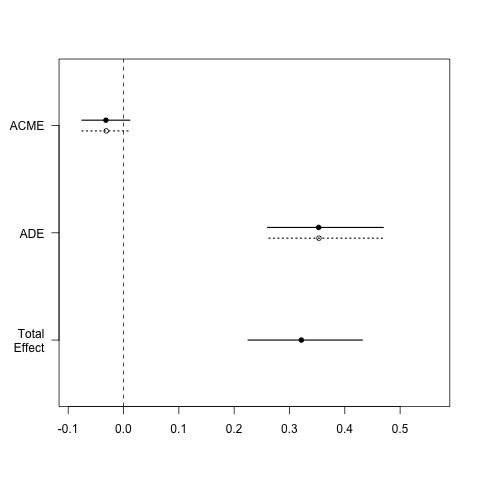

```python
%%R
#load the mediation package
library(mediation)
# here we will use the subset command to account for missing data on SCMAT
# First we explore the effect of gender on achievement
modelA <- lm(PV1MATH ~ gender, data = pisa, subset = !is.na(SCMAT) )
# Second we estimate the effect of gender and PV1MATH allowing for a treatment by mediator interaction
modelB <- lm(SCMAT ~ gender*PV1MATH, data = pisa, subset = !is.na(SCMAT) )
# Now we calculate the mediation using simulation (see help file for how to do bootstrapping)
modelAB <- mediate(modelA, modelB, treat = 'gender', mediator = 'PV1MATH', sims = 100)
# Get the results and plot them
print(summary(modelAB) )
plot(modelAB)
```

# General Linear models

## Top Tips for GLM

1. For binary variables use family=binomial(link = "logit") for logistic regression or amily=binomial(link = "probit") for probit regression
2. For counts use family = "poisson"
3. Many other data types can be covered. See ?family for details

## Running general linear models

So far we have assumed that our response variable is continous. But this is not always the case. When response variables are ordinal, nominal, binomial, or count we need to turn to general linear models.

In this section we are going to look at how strong the relationship is between objective measures of social class and self-report measures. We will run a logistic regression model and then a proportional odds regression model.

top

```python
%%R
#First lets create a blue colar versus white colar variable
# We will do this via the recode function in the car package
library(car)
pisa$socialClass <- recode(pisa$SSECATEG, "c(1,2) = 1; c(3,4) = 0")
# now we can run our logistic regression
modelLogistic <- glm(socialClass ~ ESCS, data = pisa, family = binomial(link = 'logit') )
# Summary of the model
print(summary(modelLogistic) )
# Coefs in log odds
cat("Log odds are:\n")
print(exp(coef(modelLogistic) ))
```

```
Call:
glm(formula = socialClass ~ ESCS, family = binomial(link = "logit"),
    data = pisa)

Deviance Residuals:
    Min       1Q   Median       3Q      Max
-2.4227   0.3730   0.4634   0.5579   1.0436

Coefficients:
            Estimate Std. Error z value Pr(>|z|)
(Intercept)  1.88025    0.09938  18.919  < 2e-16 ***
ESCS         0.59688    0.11984   4.981 6.34e-07 ***
---
Signif. codes:  0 ‘***’ 0.001 ‘**’ 0.01 ‘*’ 0.05 ‘.’ 0.1 ‘ ’ 1

(Dispersion parameter for binomial family taken to be 1)

    Null deviance: 719.76  on 960  degrees of freedom
Residual deviance: 694.08  on 959  degrees of freedom
  (219 observations deleted due to missingness)
AIC: 698.08

Number of Fisher Scoring iterations: 5

Log odds are:
(Intercept)        ESCS
   6.555158    1.816438
```

*Note:* It is also easy to run a probit instead of logistic. Just change link='logit' to link='probit'

## Proportional Odds Logistic Regression

The above model is fine BUT we are reducing the amount of detail in the data as there are four categories of self-reported social class rather than 2. To account for this ordinal data we can use the polr function in the MASS package.

top

```python
%%R
library(MASS)
# we need to r
modelPolr <- polr(as.factor(rev(SSECATEG)) ~ ESCS, data = pisa)
print(summary(modelPolr))

cat("Log odds are:\n")
print(exp(modelPolr$zeta))
print(exp(coef(modelPolr)))
```

```
Re-fitting to get Hessian

Call:
polr(formula = as.factor(rev(SSECATEG)) ~ ESCS, data = pisa)

Coefficients:
        Value Std. Error t value
ESCS -0.09577    0.08532  -1.122

Intercepts:
    Value   Std. Error t value
1|2  1.0894  0.0773    14.0849
2|3  1.9310  0.0999    19.3376
3|4  4.3375  0.2910    14.9066

Residual Deviance: 1464.452
AIC: 1472.452
(231 observations deleted due to missingness)
Log odds are:
      1|2       2|3       3|4
 2.972460  6.896289 76.515511
     ESCS
0.9086762
```

# Multilevel Models

## Top tips for multilevel models

1. ICC1 and ICC2 functions in the multilevel package are easy ways ti get ICCs
2. Multilevel models look exactly like lm or glm models except for the addition of a random component
3. The random component is an additional predictor and looks like (bitYouWantRandom | cluster)
4. 1 = intercept so a random intercept for school id would look like (1 | schoolId)
5. This structure is identical for either lm or glm models
6. Three or more level nesting looks like (1 | classID/schoolID )
7. Cross classification looks like (1 | schoolID) + (1 | neighbourhoodID)
8. You can use a hausman endogineity test to see whether you even need a multilevel model
9. You can compare nested multilevel models using anova()
10. Multilevel models are run from the lme4 package, however if you need to account for autoregressive errors you will need to use the nlme package

## ICC

First we will run some ICCs on achievement and self-concept

top

```python
%%R
library(multilevel)
#First we run an anova
achIcc <- aov(PV1MATH ~ as.factor(SCHOOLID.x), data = pisa)
scIcc <- aov(SCMAT ~ as.factor(SCHOOLID.x), data = pisa)
cat("ICC for achievement is:\n")
print(ICC1(achIcc) )
cat("ICC for self-concept is:\n")
print(ICC1(scIcc) )
```

```
ICC for achievement is:
[1] 0.2280439
ICC for self-concept is:
[1] 0.02210939
```

## Multilevel Models

We will look at whether we need a multilevel model to explore the relationship between achievement and self-concept using a HET. Then we compare a random intercept to a random slopes model. There is no real function for a HET in R so we will have to slightly modify an existing one taken from [stackoverflow](https://stackoverflow.com/questions/23630214/hausmans-specification-test-for-glmer-from-lme4).

top

```python
%%R
#First we need to write a function for the HET
phtest_glmer <- function (glmerMod, glmMod, ...)  {  ## changed function call
  coef.wi <- coef(glmMod)
  coef.re <- fixef(glmerMod)  ## changed coef() to fixef() for glmer
  vcov.wi <- vcov(glmMod)
  vcov.re <- vcov(glmerMod)
  names.wi <- names(coef.wi)
  names.re <- names(coef.re)
  coef.h <- names.re[names.re %in% names.wi]
  dbeta <- coef.wi[coef.h] - coef.re[coef.h]
  df <- length(dbeta)
  dvcov <- vcov.re[coef.h, coef.h] - vcov.wi[coef.h, coef.h]
  stat <- abs(t(dbeta) %*% as.matrix(solve(dvcov)) %*% dbeta)  ## added as.matrix()
  pval <- pchisq(stat, df = df, lower.tail = FALSE)
  names(stat) <- "chisq"
  parameter <- df
  names(parameter) <- "df"
  alternative <- "one model is inconsistent"
  res <- list(statistic = stat, p.value = pval, parameter = parameter,
              method = "Hausman Test",  alternative = alternative,
              data.name=deparse(glmerMod@call$data))  ## changed
  class(res) <- "htest"
  return(res)
}
#Load the lme4 package
library(lme4)
#Fixed effect model
modelFixed <- lm(SCMAT ~ PV1MATH, data = pisa)
#Random intercept model
modelRandomInt <- lmer(SCMAT ~ PV1MATH + (1|SCHOOLID.x) , data = pisa)
# Test whether a multilevel model is needed
print(phtest_glmer(modelRandomInt, modelFixed) )
# Ok so we don't really need it in this case we could get away with just using complex standard errors

# Lets fit a random slope model
modelRandomSlope <- lmer(SCMAT ~ PV1MATH + (PV1MATH|SCHOOLID.x) , data = pisa)

#Lets compare a random intercept to a random slope model
print(anova(modelRandomInt, modelRandomSlope))
```

```
	Hausman Test

data:  pisa
chisq = 5.1731, df = 2, p-value = 0.07528
alternative hypothesis: one model is inconsistent

refitting model(s) with ML (instead of REML)
Data: pisa
Models:
modelRandomInt: SCMAT ~ PV1MATH + (1 | SCHOOLID.x)
modelRandomSlope: SCMAT ~ PV1MATH + (PV1MATH | SCHOOLID.x)
                 Df    AIC    BIC  logLik deviance  Chisq Chi Df Pr(>Chisq)
modelRandomInt    4 2933.1 2953.3 -1462.5   2925.1
modelRandomSlope  6 2936.8 2967.1 -1462.4   2924.8 0.3175      2     0.8532
```

I have modified a function from [here](http://www.rensenieuwenhuis.nl/r-sessions-20-plotting-multilevel-models/) that will give a nice plot of the multilevel model.

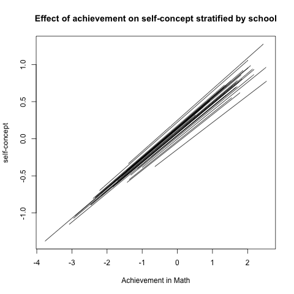

```python
%%R
#plot
visualize.lme <- function (model, coefficient, group, ...){
        r <- ranef(model)[[group]]
        f <- fixef(model)

        effects <- data.frame(r[,1]+f[1], r[,2]+f[2])

        number.lines <- nrow(effects)

        predictor.min <- tapply(model@frame[[coefficient]], model@frame[[group]], min, na.rm=TRUE)
        predictor.max <- tapply(model@frame[[coefficient]], model@frame[[group]], max, na.rm=TRUE)

        outcome.min <- min(predict(model), na.rm=TRUE)
        outcome.max <- max(predict(model), na.rm=TRUE)

        plot (c(min(predictor.min),max(predictor.max)),c(outcome.min,outcome.max), type="n", ...)

        for (i in 1:number.lines){
            expression <- function(x) {effects[i,1] + (effects[i,2] * x) }
            curve(expression, from=predictor.min[i], to=predictor.max[i], add=TRUE)
            }
        }

visualize.lme(modelRandomSlope, "PV1MATH", "SCHOOLID.x",
              xlab="Achievement in Math", ylab="self-concept",
              main="Effect of achievement on self-concept stratified by school")
```

## GLMER - Multievel models for non-linear models

We can do the same thing for our glm models. In this case we will also demostrate a three level model of students in grades within schools.

```python
%%R
#Three level model
modelGlm3level <- glmer(socialClass ~ ESCS + (1|SCHOOLID.x/yearInSchool), data = pisa, family = binomial(link = "logit") )
print(summary(modelGlm3level) )
# cross-classification model
modelGlm3level <- glmer(socialClass ~ ESCS + (1|SCHOOLID.x) + (1|yearInSchool), data = pisa, family = binomial(link = "logit") )
print(summary(modelGlm3level) )
```

```
Generalized linear mixed model fit by maximum likelihood (Laplace
  Approximation) [glmerMod]
 Family: binomial  ( logit )
Formula: socialClass ~ ESCS + (1 | SCHOOLID.x/yearInSchool)
   Data: pisa

     AIC      BIC   logLik deviance df.resid
   671.1    690.5   -331.5    663.1      957

Scaled residuals:
    Min      1Q  Median      3Q     Max
-5.0971  0.2003  0.2921  0.3891  1.2288

Random effects:
 Groups                  Name        Variance  Std.Dev.
 yearInSchool:SCHOOLID.x (Intercept) 1.107e-06 0.001052
 SCHOOLID.x              (Intercept) 7.058e-01 0.840149
Number of obs: 961, groups:  yearInSchool:SCHOOLID.x, 66; SCHOOLID.x, 29

Fixed effects:
            Estimate Std. Error z value Pr(>|z|)
(Intercept)   2.1616     0.2050  10.545  < 2e-16 ***
ESCS          0.3965     0.1408   2.815  0.00487 **
---
Signif. codes:  0 ‘***’ 0.001 ‘**’ 0.01 ‘*’ 0.05 ‘.’ 0.1 ‘ ’ 1

Correlation of Fixed Effects:
     (Intr)
ESCS -0.112
Generalized linear mixed model fit by maximum likelihood (Laplace
  Approximation) [glmerMod]
 Family: binomial  ( logit )
Formula: socialClass ~ ESCS + (1 | SCHOOLID.x) + (1 | yearInSchool)
   Data: pisa

     AIC      BIC   logLik deviance df.resid
   671.1    690.5   -331.5    663.1      957

Scaled residuals:
    Min      1Q  Median      3Q     Max
-5.0971  0.2003  0.2921  0.3891  1.2288

Random effects:
 Groups       Name        Variance  Std.Dev.
 SCHOOLID.x   (Intercept) 7.059e-01 0.8401510
 yearInSchool (Intercept) 1.987e-10 0.0000141
Number of obs: 961, groups:  SCHOOLID.x, 29; yearInSchool, 4

Fixed effects:
            Estimate Std. Error z value Pr(>|z|)
(Intercept)   2.1616     0.2050  10.545  < 2e-16 ***
ESCS          0.3965     0.1408   2.815  0.00487 **
---
Signif. codes:  0 ‘***’ 0.001 ‘**’ 0.01 ‘*’ 0.05 ‘.’ 0.1 ‘ ’ 1

Correlation of Fixed Effects:
     (Intr)
ESCS -0.112
```

*Note:* If you want to do multilevel polr models please see the ordinal package.

top

[Back to top](http://nbviewer.ipython.org/github/pdparker/rcourse/blob/master/Regression%20in%20R.ipynb#)